# Tour in Loon

Wayne Oldford and Zehao Xu

2024-04-08

```r
library(loon.tourr)
```

## Introduction

A tour is a motion graphic designed to study the joint distribution of multivariate data [Asimov (1985)](Andreas Buja and Asimov 1986). A sequence of low-dimensional projections is created by a high dimensional data set. Tours are thus used to find interesting projections. Between each plane, interpolation along a geodesic path is provided so that the points in a sub space (e.g. 2D) can be rotated smoothly. In mathematics, $\boldsymbol{X}_{n \times p}$ represents the original data set; $\boldsymbol{P}_{p \times d}$ is the matrix of projection vectors where $d < p$.
$$\boldsymbol{Y} = \boldsymbol{X}
\boldsymbol{P}$$
where $\boldsymbol{Y}$ is the lower dimensional sub-space.

The tour was **first** implemented in the software `Dataviewer` [A. Buja, Asimov, and Hurley (1986)](Hurley 1987)(Andreas Buja, Hurley, and McDonald 1987) in Symbolics Lisp machine. A smoothly moving scatterplot could be produced to visualize the tour paths. Then, D. F. Swayne, Cook, and Buja (1991) implemented software `XGobi` in the **X** Window System, providing portability across **a wide variety of workstations** i.e. X terminals, personal computers, even across a network. Software `GGobi` [D. Swayne et al. (2001)](Cook, Swayne, and Buja 2007), **redesigned and extended** its ancestor `XGobi`. It can be embedded in other software, like environment `R`. Package `rggobi` (Lang et al. 2018) is an `R` interface of `GGobi`, however, it has been removed from the CRAN and can only be accessed from the [archive](https://cran.r-project.org/src/contrib/Archive/rggobi/).

Package `tourr` (Wickham et al. 2011) implements geodesic interpolation and variety tour generation functions (i.e. grand tour, guided tour, etc) in `R` language. The function `animate` provides tour animation as a kinematic sequence of static displays – plots are generated and then displayed quickly in order. In an RStudio display, for example, the user can cycle back and forth through the sequence … but that is all. Unlike earlier tour implementations (`rggobi`) no interactive manipulation of the plot elements is possible.

The loon package (Waddell and Oldford 2020) is a toolkit that enables highly interactive data visualization. The package **loon.tourr** adds the full functionality of loon’s interactive graphics to `tourr`. For example, this allows interactive selection, colouring, and deactivating of points in the tour display and linking that display with any other loon plot. Interesting projections discovered during the tour can be accessed at any point in the tour. In addition, random tours displaying more than 2 dimensions are also provided using parallel or radial coordinates and scatterplot matrices.

## Basics

The `crabs` (Campbell and Mahon 1974) data frame (stored in package `MASS`) contains 200 observations and 8 features, describing 5 morphological measurements on 50 crabs each of two colour forms and both sexes. GIF 1 shows the tours and color represents the species, “B” (blue) or “O” (orange).

```r
library(MASS, quietly = TRUE)
kable(head(crabs, 6))
```

| sp | sex | index | FL | RW | CL | CW | BD |
| --- | --- | --- | --- | --- | --- | --- | --- |
| B | M | 1 | 8.1 | 6.7 | 16.1 | 19.0 | 7.0 |
| B | M | 2 | 8.8 | 7.7 | 18.1 | 20.8 | 7.4 |
| B | M | 3 | 9.2 | 7.8 | 19.0 | 22.4 | 7.7 |
| B | M | 4 | 9.6 | 7.9 | 20.1 | 23.1 | 8.2 |
| B | M | 5 | 9.8 | 8.0 | 20.3 | 23.0 | 8.2 |
| B | M | 6 | 10.8 | 9.0 | 23.0 | 26.5 | 9.8 |

This plot is interactive. Users can pan, zoom or select on this plot. The default number of random bases is 30 and the steps between two serial projections are 40. So, we have 1200 + 1 (start position) projections in total. To navigate the tour, scroll the rightmost bar down, the projection is transformed from one to another. If, unfortunately, none of the projections is interesting, click the “refresh” button at the left-bottom corner. New random tours are created.

Immediately below the plot, behind the “refresh” button, there are several radio buttons, “data”, “variable”, “observation” and “sphere” that represent the scaling methods $f$ of $\boldsymbol{X}$.

- The first of which is “data”, where $f(\boldsymbol{X}) = \boldsymbol{X}$;
- If `scaling = "variable"`, $f(\mathbf{x}_j) = \frac{1}{a - b}(\mathbf{x}_j - b\mathbf{1})$ where $\boldsymbol{X} = [\mathbf{x}_{1}, ..., \mathbf{x}_{p}]$, $\mathbf{x}_{j}$ is a $n \times 1$ vector, $a = \max{(\mathbf{x}_j)}$ and $b = \min{(\mathbf{x}_j)}$;
- The third is “observation”, where $f(\mathbf{x}_i) = \frac{1}{c - d}(\mathbf{x}_i - d\mathbf{1})$, $\boldsymbol{X} = {[{\mathbf{x}_{1}}^{\mkern-1.5mu\mathsf{T}}, ..., {\mathbf{x}_{n}}^{\mkern-1.5mu\mathsf{T}}]}^{\mkern-1.5mu\mathsf{T}}$, $\mathbf{x}_{i}$ is a $p \times 1$ vector, $c = \max{(\mathbf{x}_i)}$ and $d = \min{(\mathbf{x}_i)}$;
- If the scaling method is “sphere”, where $f(\boldsymbol{X}) = \boldsymbol{X}^\star \boldsymbol{V}$ where $\boldsymbol{X}^\star = (\boldsymbol{I} - \frac{1}{n}\mathbf{1}{\mathbf{1}}^{\mkern-1.5mu\mathsf{T}})\boldsymbol{X} = \boldsymbol{U} \boldsymbol{D} \boldsymbol{V}$.

Notice that the tour is based on the transformed data set
$$\boldsymbol{Y} = f(\boldsymbol{X})
\boldsymbol{P}$$

```r
color <- rep("skyblue", nrow(crabs))
color[crabs$sp == "O"] <- "orange"
cr <- crabs[, c("FL", "RW", "CL", "CW", "BD")]
p0 <- l_tour(cr, color = color)
```

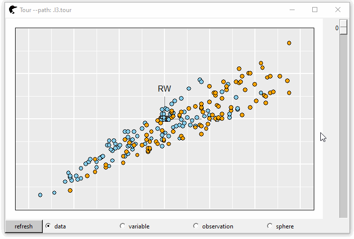

GIF 1: 2D grand tour

The projection dimension (the dimension of the $\boldsymbol{P}$) is controlled by `tour_path = grand_tour(d)` where $d$ represents the dimensions and the default is $2$. Unlike the 2 dimensional Cartesian coordinate, higher dimensional space ($>2$) will be embedded in the parallel coordinate or radial coordinate. In GIF 2, the $d$ is set as 4.

```r
p1 <- l_tour(cr,
             tour_path = grand_tour(4L),
             color = color)
```

[figure not shown]

GIF 2: 4D grand tour

An `l_tour` object is returned by `p1` (or `p0`).

```r
class(p1) # class(p0)
# > [1] "l_tour" "loon"
```

The loon serialaxes plot for `p1` (or scatterplot for `p0`) can be accessed by calling `l_getPlots`

```r
w <- l_getPlots(p1)
class(w)
# > [1] "l_serialaxes" "loon"
```

```r
round(p1["projection"], 2)
# >
#       [,1]  [,2]  [,3]  [,4]
# [1,] -0.12 -0.93 -0.01 -0.35
# [2,] -0.57  0.21  0.63 -0.36
# [3,] -0.06  0.14  0.14 -0.38
# [4,] -0.37  0.23 -0.76 -0.47
# [5,] -0.72 -0.14 -0.12  0.62
```

The radial coordinate can be converted to a parallel coordinate by calling `[<-` in the console or trigger the “parallel” radio button of “axes layout” on `p1`’s inspector.

```r
p1["axesLayout"] <- "parallel"
```

Additionally, Andrews plot can be shown by runing the following code in console

```r
p1["andrews"] <- TRUE
```

The interactive graphics can be turned to static either by

```r
plot(p1)
```

or

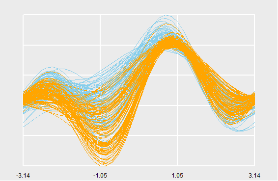

Figure 1: Andrews curve

```r
loon.ggplot::loon.ggplot(p1)
```

To investigate more about `loon`, please visit [great-northern-diver-loon](https://great-northern-diver.github.io/loon/index.html).

## Tour techniques

Cook, Swayne, and Buja (2007) introduced several methods for choosing projections. In `loon.tourr`, by modifying the argument `tour_path`, all can be realized.

- Grand tour: a sequence of projections is chosen randomly

  ```r
  # Default, 2D grand tour
  pg <- l_tour(cr, tour_path = grand_tour(2L))
  ```

- Projection pursuit guided tour: a sequence of projections is guided by an algorithm in search of “interesting” projections by optimizing a criterion function

  $$\mathop{\mathrm{arg\,max}}g(\boldsymbol{Y}),
  \forall \boldsymbol{P}$$
  where $\boldsymbol{Y} = {[{\mathbf{y}}^{\mkern-1.5mu\mathsf{T}}_1, ..., {\mathbf{y}}^{\mkern-1.5mu\mathsf{T}}_n]}^{\mkern-1.5mu\mathsf{T}} = \boldsymbol{X} \boldsymbol{P}$, $\mathbf{y}_j$ is a $p \times 1$ vector.
  - Holes:

    $$g(\boldsymbol{Y}) = \frac{1 -
    \frac{1}{n}\sum_{i=1}^n
    \exp(-\frac{1}{2}{\mathbf{y}}^{\mkern-1.5mu\mathsf{T}}_i\mathbf{y}_i)}{1
    - \exp{(-\frac{p}{2})}}$$

    ```r
    # 2D holes projection pursuit indexes
    pp_holes <- l_tour(cr, tour_path = guided_tour(holes(), 2L))
    ```

  - Central Mass:

    $$g(\boldsymbol{Y}) =
    \frac{\frac{1}{n}\sum_{i=1}^n
    \exp(-\frac{1}{2}{\mathbf{y}}^{\mkern-1.5mu\mathsf{T}}_i \mathbf{y}_i) -
    \exp{(-\frac{p}{2})}}{1 - \exp{(-\frac{p}{2})}}$$

    ```r
    # 2D CM projection pursuit indexes
    pp_CM <- l_tour(cr, tour_path = guided_tour(cmass(), 2L))
    ```

  - LDA

    $$g(\boldsymbol{Y}) = 1 -
    \frac{|{\boldsymbol{P}}^{\mkern-1.5mu\mathsf{T}}\boldsymbol{W}\boldsymbol{P}|}{|{\boldsymbol{P}}^{\mkern-1.5mu\mathsf{T}}(\boldsymbol{W}
    + \boldsymbol{B})\boldsymbol{P}|}$$

    where $\boldsymbol{B} = \sum_{i=1}^k n_i (\bar{y}_{i.} - \bar{y}_{..}) {(\bar{y}_{i.} - \bar{y}_{..})}^{\mkern-1.5mu\mathsf{T}}$, $\boldsymbol{W} = \sum_{i=1}^k \sum_{j=1}^{n_i} n_i (\bar{y}_{ij} - \bar{y}_{i.}) {(\bar{y}_{ij} - \bar{y}_{i.})}^{\mkern-1.5mu\mathsf{T}}$ and $k$ is the number of groups.

    ```r
    # 2D LDA projection pursuit indexes
    pp_LDA <- l_tour(cr,
                     color = crabs$sex,
                     tour_path = guided_tour(lda_pp(crabs$sex), 2L))
    ```

- Expect these, `tourr` also provides some other tour methods, for example:
  - `frozen_tour`, one variable is designated as the “manipulation variable”, and the projection coefficient for this variable is controlled;
  - `little_tour`, a planned tour that travels between all axis parallel projections;
  - `local_tour`, alternates between the starting position and a nearby random projection and etc.

## Compound plot

### Facets

GIF 3 shows the tour plot separated by variable sex into two panels.

```r
pf <- l_tour(cr,
             by = crabs$sex,
             color = color)
```

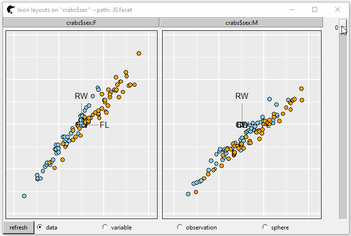

GIF 3: facets

### Pairs plot

GIF 4 shows the tour pairs plot (the upper triangle). If we set `showSerialAxes = TRUE`, a serial axes plot (parallel or radial axes) is displayed at the lower triangle.

[figure not shown]

GIF 4: pairs plot

```r
pp <- l_tour_pairs(cr,
                   tour_path = grand_tour(4L),
                   color = color,
                   showSerialAxes = TRUE)
```

Tour compound plot is a `l_tour_compound` object

```r
class(pp) # or class(pf)
# > [1] "l_tour_compound" "loon"
```

The loon pairs plot can be accessed by calling `l_getPlots`. It will return a `l_compound` widget that a list contains seven `loon` widgets.

```r
wp <- l_getPlots(pp)
wp
# >
# $x2y1
# [1] ".l0.pairs.plot"
# attr(,"class")
# [1] "l_plot" "loon"
#
# $x3y1
# [1] ".l0.pairs.plot1"
# attr(,"class")
# [1] "l_plot" "loon"
#
# $x4y1
# [1] ".l0.pairs.plot2"
# attr(,"class")
# [1] "l_plot" "loon"
#
# $x3y2
# [1] ".l0.pairs.plot3"
# attr(,"class")
# [1] "l_plot" "loon"
#
# $x4y2
# [1] ".l0.pairs.plot4"
# attr(,"class")
# [1] "l_plot" "loon"
#
# $x4y3
# [1] ".l0.pairs.plot5"
# attr(,"class")
# [1] "l_plot" "loon"
#
# $serialAxes
# [1] ".l0.pairs.serialaxes"
# attr(,"class")
# [1] "l_serialaxes" "loon"
#
# attr(,"class")
# [1] "l_pairs"    "l_compound" "loon"
```

Note that all the plots in a single compound widget share the same projection (e.g `pp['projection']`).

## Layers

Sometimes, layering visuals in a tour is helpful to find an interesting “pattern”.

### `l_layer_hull`

A convex hull is the smallest convex set that contains it. We can add such layer by `l_layer_hull`

```r
# pack layer on top of `p0`
l0 <- l_layer_hull(p0, group = crabs$sp)
```

The argument `group` is used to clarify the group of the set in each hull. Suppose we want to find a projection that splits the crab species well, layering the hull could be extremely useful. If two hulls have no intersections, this projection could be the one we are looking for.

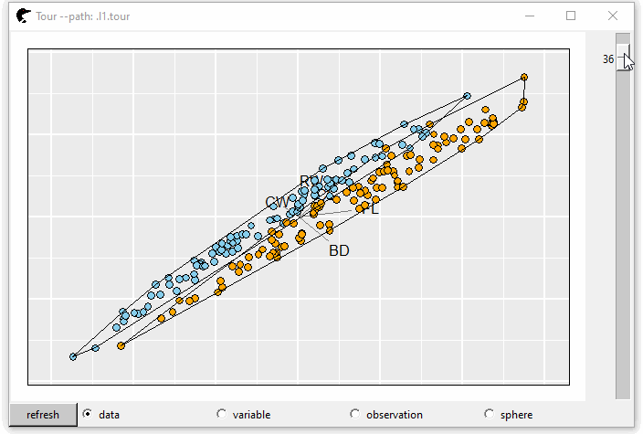

GIF 5: layer hull

### `l_layer_density2d`

Two dimensional kernel density estimation can tell the dense of a distribution.

```r
# hide the hull
l_layer_hide(l0)
# density2D
l1 <- l_layer_density2d(p0)
```

[figure not shown]

GIF 5: layer density

### `l_layer_trails`

Display trails in tours

```r
# hide the density2D
l_layer_hide(l1)
# density2D
l2 <- l_layer_trails(p0)
```

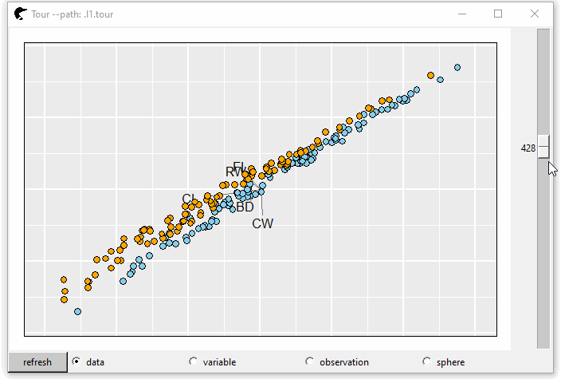

The trails can show the direction of the projection. Meanwhile, the lengths of tails represent the steps of each transformation.

### Build your own layers

The interactive layers are realized by modifying function `l_layer_callback`. **It is a generic function and the class is determined by `label`**. For example, we want to create a static point layer and make it as a background of the object `pf`.

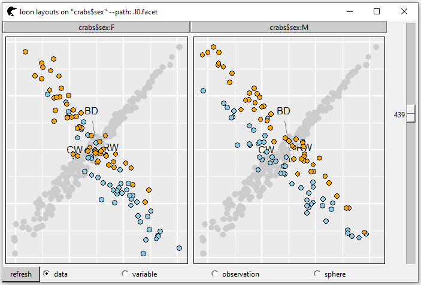

Figure 2: non-interactive layer

```r
allx <- unlist(pf['x'])
ally <- unlist(pf['y'])
layers <- lapply(l_getPlots(pf),
                 function(p) {
                   l <- loon::l_layer_points(p,
                                             x = allx,
                                             y = ally,
                                             color = "grey80",
                                             label = "background")
                   # set the layer as the background
                   loon::l_layer_lower(p, l)
                 })
```

- `target`: a **`l_tour`** object.
- `layer`: a layer to be turned into interactive.
- `...` includes that:
  - start: the start matrix of projection vectors $\boldsymbol{P}_s$
  - initialTour: the activated panel’s initial position $\boldsymbol{Y}_s$ where $\boldsymbol{Y}_s = \boldsymbol{X} \boldsymbol{P}_s$.
  - projections: A list of the activated panel’s projection matrices.
  - tours: A list of the activated panel’s tour path ($\boldsymbol{Y}$).
  - group: a factor defines the grouping of the activated panel.
  - var: scroll bar current variable.
  - varOld: scroll bar previous variable.
  - color: the activated panel’s objects’ (points’ or lines’) color.
  - axes: only for scatterplot, the guided axes.
  - labels: only for scatterplot, the guided labels.
  - axesLength: only for scatterplot, the guided axes length.
  - *If the layer is added for a `l_tour_compound` object*
    - l_compound: a `l_compound` widget
    - allTours: returns the tour path for all panels.
    - allInitialTour: returns the initial position for all panels.
    - allProjections: returns the projection matrices for all panels.
    - allColor: returns the color for all panels

  Notice that, there is no need to use all these to build an interactive statistical layer. For example, in function `l_layer_callback.background`, we only extract two parameters `allTours` (the tours for all panels) and `var` (the current scroll bar variable).

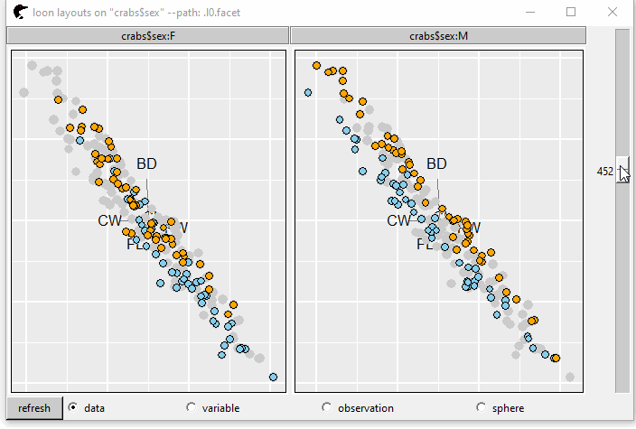

GIF 7: interactive layer

```r
l_layer_callback.background <- function(target, layer, ...) {

  widget <- l_getPlots(target)
  layer <- loon::l_create_handle(c(widget, layer))

  args <- list(...)
  # the overall tour paths
  allTours <- args$allTours
  # the scale bar variable
  var <- args$var
  # the current projection (bind both facets)
  proj <- do.call(rbind, allTours[[var]])

  loon::l_configure(layer,
                    x = proj[, 1],
                    y = proj[, 2])
}
```

After function `l_layer_callback.background` is created and executed, the layer is interactive.

## Reference

Asimov, Daniel. 1985. “The Grand Tour: A Tool for Viewing Multidimensional Data.” *SIAM Journal on Scientific and Statistical Computing* 6 (1): 128–43.

Buja, A, D Asimov, and C Hurley. 1986. *Elements of a Viewing Pipeline for Data Analysis*. Bell Communications Research. Morris Research; Engineering Center ….

Buja, Andreas, and Daniel Asimov. 1986. “Grand Tour Methods: An Outline.” *Computing Science and Statistics* 17: 63–67.

Buja, Andreas, Catherine Hurley, and Johnalan McDonald. 1987. “A Data Viewer for Multivariate Data.” In *Colorado State Univ, Computer Science and Statistics. Proceedings of the 18 Th Symposium on the Interface p 171-174(SEE n 89-13901 05-60)*.

Campbell, NA, and RJ Mahon. 1974. “A Multivariate Study of Variation in Two Species of Rock Crab of the Genus Leptograpsus.” *Australian Journal of Zoology* 22 (3): 417–25.

Cook, Dianne, Deborah F Swayne, and Andreas Buja. 2007. *Interactive and Dynamic Graphics for Data Analysis: With r and GGobi*. Springer Science & Business Media.

Hurley, Catherine. 1987. “The Data Viewer: A Program for Graphical Data Analysis.” PhD thesis, Citeseer.

Lang, Duncan Temple, Debby Swayne, Hadley Wickham, and Michael Lawrence. 2018. *Rggobi: Interface Between r and ’GGobi’*. https://CRAN.R-project.org/package=rggobi.

Swayne, Deborah F, Dianne Cook, and Andreas Buja. 1991. “XGobi: Interactive Dynamic Graphics in the x Window System with a Link to s.”

Swayne, D, Duncan Temple Lang, Andreas Buja, and Dianne Cook. 2001. “GGobi: XGobi Redesigned and Extended.” In *Proceedings of the 33th Symposium on the Interface: Computing Science and Statistics*. Citeseer.

Waddell, Adrian, and R. Wayne Oldford. 2020. *Loon: Interactive Statistical Data Visualization*. https://great-northern-diver.github.io/loon/.

Wickham, Hadley, Dianne Cook, Heike Hofmann, and Andreas Buja. 2011. “tourr: An R Package for Exploring Multivariate Data with Projections.” *Journal of Statistical Software* 40 (2): 1–18. https://www.jstatsoft.org/v40/i02/.